# HW4: RMarkdown

Yichien Chou

2020/10/10

# Outline

- Data Description
- Statistical Methods
  - One sample t-test
  - ANOVA
  - Regression

# Statistical Topic: *mtcars*

## Data Description

The data was extracted from the 1974 Motor Trend US magazine, and comprises fuel consumption and 10 aspects of automobile design and performance for 32 automobiles (1973–74 models).

[figure not shown]

*To learn more, please visit https://rpubs.com/BillB/217355.*

```r
#data("mtcars")
#dim(mtcars) #32obs. and 11 vars.
mtcars$vs <- as.factor(mtcars$vs)
mtcars$am <- as.factor(mtcars$am)

head(mtcars)
```

```
##                    mpg cyl disp  hp drat    wt  qsec vs am gear carb
## Mazda RX4         21.0   6  160 110 3.90 2.620 16.46  0  1    4    4
## Mazda RX4 Wag     21.0   6  160 110 3.90 2.875 17.02  0  1    4    4
## Datsun 710        22.8   4  108  93 3.85 2.320 18.61  1  1    4    1
## Hornet 4 Drive    21.4   6  258 110 3.08 3.215 19.44  1  0    3    1
## Hornet Sportabout 18.7   8  360 175 3.15 3.440 17.02  0  0    3    2
## Valiant           18.1   6  225 105 2.76 3.460 20.22  1  0    3    1
```

## 1. One sample t-test

Suppose we want to test if the mean Miles/(US) gallon was 30. The null and alternative hypothesis was as below,

$\mathbf{H_o: µ=30}$ **vs.** $\mathbf{H_a: µ \ne 30}$

### Check the assumptions

Before performing the t test, we need to see if the sample satisfied the assumptions.

#### 1. Normality

To check whether the response variable fits a normal distribution, we can apply **Shapiro-Wilk normality test** to the response variable *mpg*:

```r
shapiro.test(mtcars$mpg)
```

```
##
##  Shapiro-Wilk normality test
##
## data:  mtcars$mpg
## W = 0.94756, p-value = 0.1229
```

Since p=0.1229, thus we do not reject the null hypothesis. That is, we assume the response fits a normal distribution.

#### 2. Independence of observations

We assume observations were randomly selected.

#### 3. Homogeneity of variance among groups

We assume the variation within each group is similar across all groups.

### Perform the t test

```r
#T test
t.test(mtcars$mpg, mu = 30)
```

[output not shown]

*t: Test statistic from the t-test.

*Df: Degrees of freedom for the independent variable.

## 2. ANOVA

Suppose we want to see if there was a difference in average Miles/(US) gallon between the type of engine (V-shape and straight).

The null and alternative hypothesis was as below,

$\mathbf{H_o: µ_V=µ_S}$ **vs.** $\mathbf{H_a: µ_V \ne µ_S}$

### Check the assumptions

Similarly, before performing the ANOVA test, we need to see if the sample satisfied the assumptions.

#### 1. Normality

To check whether the response variable fits a normal distribution, we can make a histogram of the response variable:

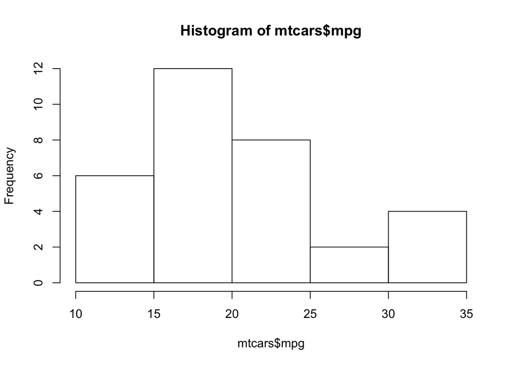

```r
hist(mtcars$mpg)
```

The response seems did not fit a normal distribution, so we should use a log transform or other methods to make it satisfied the normality assumption. But now we just assume it fits the normality.

#### 2. Independence of observations

We assume observations were randomly selected.

#### 3. Homogeneity of variance among groups

We assume the variation within each group is similar across all groups.

### Perform the ANOVA test

```r
#one-way ANOVA
mtcars.anova <- aov(mpg ~ vs, data = mtcars)
summary(mtcars.anova)
```

```
##             Df Sum Sq Mean Sq F value   Pr(>F)
## vs           1  496.5   496.5   23.66 3.42e-05 ***
## Residuals   30  629.5    21.0
## ---
## Signif. codes:  0 '***' 0.001 '**' 0.01 '*' 0.05 '.' 0.1 ' ' 1
```

*Df: Degrees of freedom for the independent variable.

*Sum Sq: Sum of square.

*Mean Sq: Mean of the sum of square.

*F-value: Test statistic from the F-test.

*Pr(>F): p-value of the F-test.

### Conclusion

The p-value is less than 0.0001, so we can conclude that the type of engine has a significant impact on the *miles/(US)gallon*.

## 3. Regression

Suppose we aimed to find the relationship between **miles/(US) gallon** and **gross horsepower**.

### Check the assumptions

#### 1. Normality

Same as the previous two tests, we can use the *hist* function to check this assumption.

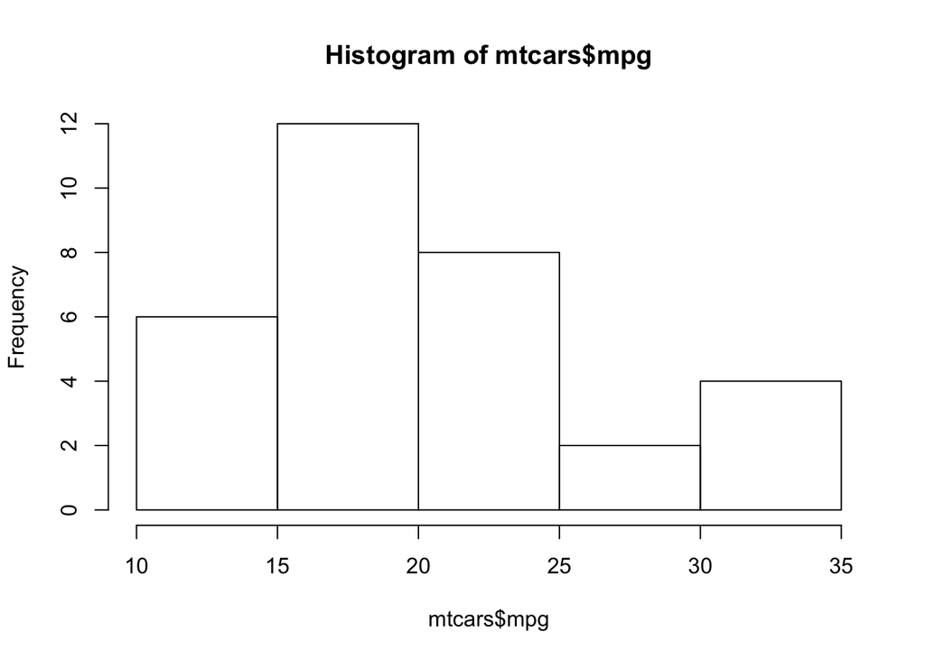

```r
hist(mtcars$mpg)
```

#### 2. Independence of observations

We assume observations were randomly selected.

#### 3. Homogeneity of variance among groups

We assume the variation within each group is similar across all groups.

#### 4. Linearity

The relationship between the independent and dependent variable must be linear. We use the *plot* function to visualize it.

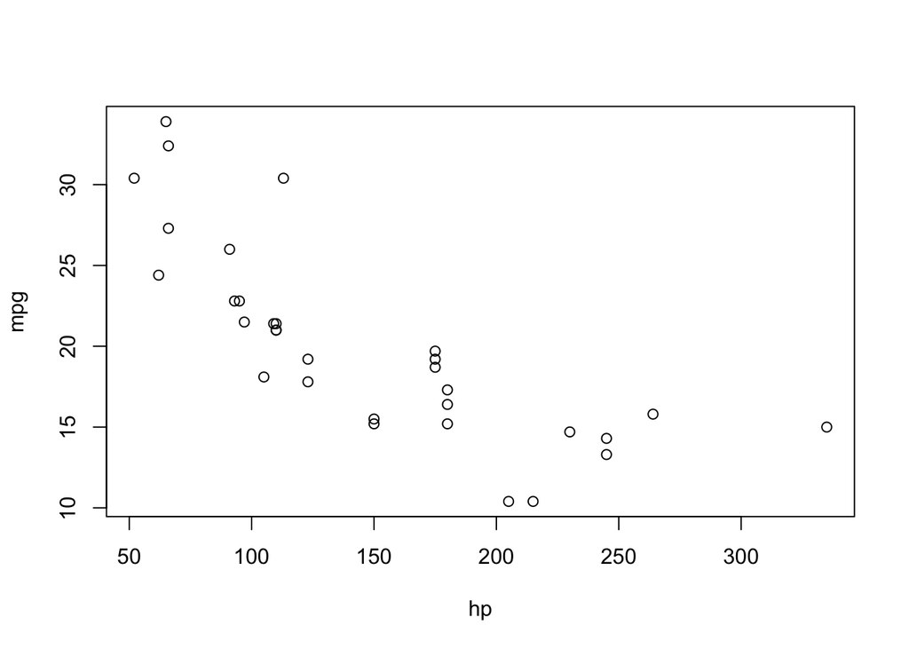

```r
plot(mpg ~ hp, data = mtcars)
```

The relationship looks roughly linear, so we can proceed with the linear model.

### Perform the linear regression

```r
mtcars.lm <- lm(mpg ~ hp, data = mtcars)
summary(mtcars.lm)
```

```
##
## Call:
## lm(formula = mpg ~ hp, data = mtcars)
##
## Residuals:
##     Min      1Q  Median      3Q     Max
## -5.7121 -2.1122 -0.8854  1.5819  8.2360
##
## Coefficients:
##             Estimate Std. Error t value Pr(>|t|)
## (Intercept) 30.09886    1.63392  18.421  < 2e-16 ***
## hp          -0.06823    0.01012  -6.742 1.79e-07 ***
## ---
## Signif. codes:  0 '***' 0.001 '**' 0.01 '*' 0.05 '.' 0.1 ' ' 1
##
## Residual standard error: 3.863 on 30 degrees of freedom
## Multiple R-squared:  0.6024, Adjusted R-squared:  0.5892
## F-statistic: 45.46 on 1 and 30 DF,  p-value: 1.788e-07
```

### Conclusion

We can say that there is a significant negative relationship between **miles/(US) gallon** and **gross horsepower** (p-value < 0.001), with a 0.068-unit decrease in **miles/(US) gallon** for every unit increase in **gross horsepower**.

### Model Comparison

Now, we add **number of forward gears** into the model, to see if it improves the model performance:

```r
mtcars.lm2 <- lm(mpg ~ hp + gear, data = mtcars)
summary(mtcars.lm2)
```

```
##
## Call:
## lm(formula = mpg ~ hp + gear, data = mtcars)
##
## Residuals:
##     Min      1Q  Median      3Q     Max
## -4.7977 -2.4288 -0.7685  2.2405  7.5943
##
## Coefficients:
##              Estimate Std. Error t value Pr(>|t|)
## (Intercept) 17.755144   3.241809   5.477 6.74e-06 ***
## hp          -0.063931   0.008206  -7.791 1.36e-08 ***
## gear         3.176520   0.762584   4.165 0.000255 ***
## ---
## Signif. codes:  0 '***' 0.001 '**' 0.01 '*' 0.05 '.' 0.1 ' ' 1
##
## Residual standard error: 3.108 on 29 degrees of freedom
## Multiple R-squared:  0.7513, Adjusted R-squared:  0.7341
## F-statistic: 43.79 on 2 and 29 DF,  p-value: 1.731e-09
```

[output not shown]

As the result, the model with both gross horsepower and the number of forward gears has a better performance than the original model.

# Other functions in RMarkdown

## 1. Changing chunk background color

We can customize the style of code chunks and their text output using the chunk options **class.source** and **class.output**, respectively.

By default, the HTML output of R Markdown includes the Bootstrap framework, which makes it easy for you to change the appearance of your code and output, because Bootstrap has predefined some CSS classes for backgrounds: “bg-primary”, “bg-success”, “bg-info”, “bg-warning”, and “bg-danger”.

````r
#For example
#```{r, class.source="bg-danger", class.output="bg-warning", class.source="bg-success"}
#```
````

Reference : https://bookdown.org/yihui/rmarkdown-cookbook/chunk-styling.html

## 2. Font Color

The Markdown syntax has no built-in method for changing text colors. We can use HTML and LaTeX syntax to change the formatting of words:

For HTML, we can wrap the text in the tag and set the color with CSS.

```r
<span style="color: red;">text</span>
```

You can add any words in the *text*.

For example:

```r
Some Markdown text with <span style="color: red;">red is so cool</span>
```

The result: Some Markdown text with red is so cool

Another example:

```r
The text can also become <span style="color: orange;">orange</span>, <span style="color: yellow;">yellow</span>,  <span style="color: green;">green</span>, <span style="color: blue;">blue</span>, <span style="color: purple;">purple</span>
```

The text can also become orange, yellow, green, blue, purple

Reference: https://bookdown.org/yihui/rmarkdown-cookbook/font-color.html

[figure not shown]